# Applying Predictions on the Insurance Dataset

Pablo Castillo Garita

2024-06-30

## 1. Loading and cleaning Data

Before loading the csv file, you have to visualize the csv in a notepad, to know which arguments to assign to the `read.csv` function. In this case it has a header, has qualitative variables that can be converted into factors and uses a semicolon as a separator.

```r
seguro <- read.csv(
  "Seguros.csv",
  header = TRUE,
  stringsAsFactors = TRUE,
  sep = ";"
)
```

After loading the data it is advisable to do a `str` on the dataframe to know if the data was loaded correctly.

```r
str(seguro)
```

```
## 'data.frame':    6413 obs. of  12 variables:
##  $ Interes       : int  17 17 12 17 17 17 17 17 18 17 ...
##  $ Tipo          : Factor w/ 2 levels "Internacional",..: 2 2 2 2 2 2 2 2 2 2 ...
##  $ MontoAsegurado: int  462045 310530 606894 3037803 650227 462045 310530 613561 189318 3187842 ...
##  $ TipoPago      : Factor w/ 3 levels "A","B","C": 1 1 1 2 1 2 1 1 1 2 ...
##  $ ModoPago      : Factor w/ 3 levels "Cajas","NoDefinido",..: 3 3 3 3 3 3 3 3 3 3 ...
##  $ Fiador        : Factor w/ 2 levels "No","Si": 1 2 1 1 2 2 1 1 1 1 ...
##  $ Fiador2       : Factor w/ 2 levels "No","Si": 1 2 1 1 1 1 1 1 1 1 ...
##  $ OtroSeguro    : Factor w/ 2 levels "No","Si": 2 2 2 1 1 1 1 1 1 1 ...
##  $ Record        : Factor w/ 8 levels "R0","R1","R2",..: 3 2 3 1 1 1 1 1 1 1 ...
##  $ Edad          : int  39 32 32 40 32 34 33 38 35 39 ...
##  $ EstadoCivil   : Factor w/ 5 levels "Divorciado","NoAplica",..: 3 3 3 3 3 3 3 3 3 3 ...
##  $ Fraude        : Factor w/ 2 levels "No","Si": 1 1 1 1 1 1 1 1 1 1 ...
```

We can convert the variable interest into an ordered factor.

```r
seguro$Interes <- factor(seguro$Interes, ordered = TRUE)
```

It is of great importance to check if there are null values in the dataframe and if there are, to impute them. In this case there are not.

```r
sum(is.na(seguro))
```

```
## [1] 0
```

The density of the variable to be predicted will be displayed as follows.

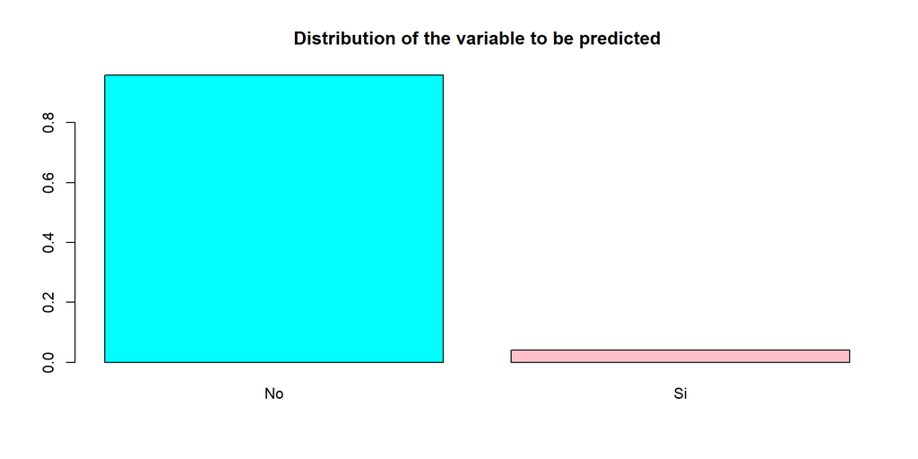

As can be seen in the density plot above, the problem is highly unbalanced. It may be more difficult to accurately predict the `Fraude` variable.

## 2. Training and Testing Table

Now we divide the data into two tables to create the training table and the testing table, this division will be 75-25, that is 75% of the data for the training table and the remaining 25% for the testing table.

```r
size <- dim(seguro)
n <- size[1]
sample <- sample(1:n, floor(n * 0.25))

training_table <- seguro[-sample, ]
testing_table <- seguro[sample, ]
```

## 3. Function to Calculate Metrics

This is a function that will help us to calculate the main indicators of the confusion matrices and to know how good our prediction model is.

```r
calculate_metrics <- function(confusion_matrix) {
  TN <- confusion_matrix[1,1]
  FN <- confusion_matrix[2,1]
  FP <- confusion_matrix[1,2]
  TP <- confusion_matrix[1,1]
  N <- TN + FP
  P <- FN + TP

  global_accuracy <- sum(diag(confusion_matrix)) / sum(confusion_matrix)
  global_error <- 1 - global_accuracy
  positive_precision <- TP/P
  negative_precision <- TN/N
  false_positives <- FP/(TN+FP)
  false_negatives <- FN/(FN+TP)
  positive_assertivity <- TP/(FP+TP)
  negative_assertivity <- TN/(TN+FN)
  category_accuracy <- diag(confusion_matrix) / rowSums(confusion_matrix)

  results <- list(
    confusion_matrix = round(confusion_matrix, 4),
    global_accuracy = round(global_accuracy, 4),
    global_error = round(global_error, 4),
    positive_precision = round(positive_precision, 4),
    negative_precision = round(negative_precision, 4),
    false_positives = round(false_positives, 4),
    false_negatives = round(false_negatives, 4),
    positive_assertivity = round(positive_assertivity, 4),
    negative_assertivity = round(negative_assertivity, 4),
    category_accuracy = round(category_accuracy, 4)
  )

  names(results) <- c(
    "Confusion Matrix",
    "Global Accuracy",
    "Global Error",
    "Positive Precision",
    "Negative Precision",
    "False Positives",
    "False Negatives",
    "Positive Assertivity",
    "Negative Assertivity",
    "Category Accuracy"
  )

  return(results)
}
```

## 4. Predictive Models without calibration

The following predictive models will now be applied to find out which one best fits our data.

### a. k-Nearest Neighbor Classifier

```r
library(kknn)

model_kknn <- train.kknn(Fraude ~ ., data = training_table, kmax = floor(sqrt(n)))
prediction_kknn <- predict(model_kknn, testing_table[, -12])
cm_kknn <- table(testing_table[, 12], prediction_kknn)
res_kknn <- calculate_metrics(cm_kknn)
```

### b. Decision Trees

```r
library(rpart)

model_DT <- rpart(Fraude ~ ., data = training_table)
prediction_DT <- predict(model_DT, testing_table, type = "class")
cm_DT <- table(testing_table$Fraude, prediction_DT)
res_DT <-  calculate_metrics(cm_DT)
```

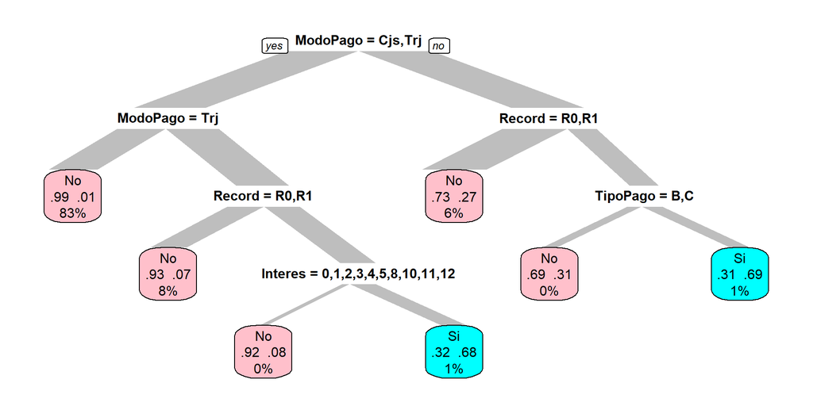

```r
library(rpart.plot)

prp(model_DT, extra=104, branch.type=2, box.col=c("pink","cyan")[model_DT$frame$yval])
```

### c. Random Trees

```r
library(randomForest)

model_RF <- randomForest(Fraude ~ ., data = training_table, importance = TRUE)
prediction_RF <- predict(model_RF, testing_table[, -12])
cm_RF <- table(testing_table$Fraude, prediction_RF)
res_RF <- calculate_metrics(cm_RF)
```

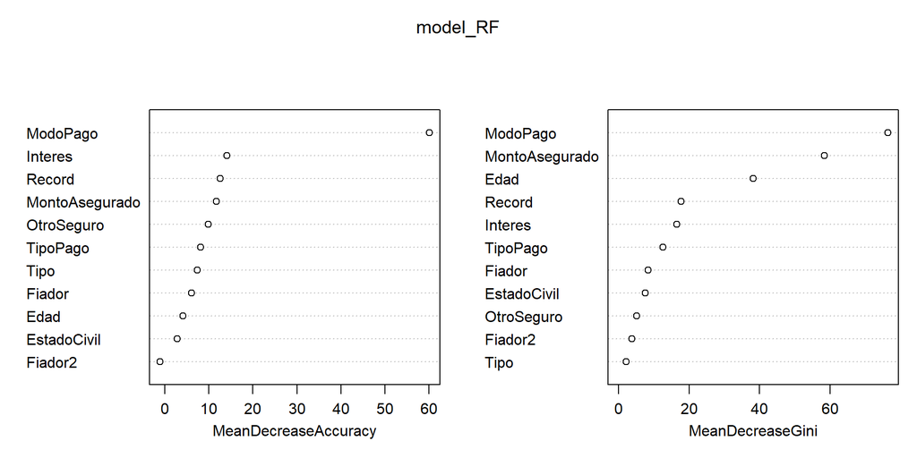

```r
varImpPlot(model_RF)
```

### d. Support Vector Machines (SVM)

```r
library(e1071)
```

#### i. Kernel Linear

```r
model_linear <- svm(Fraude ~ ., data = training_table, kernel = "linear")
prediction_linear <- predict(model_linear, testing_table)
cm_linear <- table(testing_table[, 12], prediction_linear)
res_linear <- calculate_metrics(cm_linear)
```

#### ii. Kernel Radial

```r
model_radial <- svm(Fraude ~ ., data = training_table, kernel = "radial")
prediction_radial <- predict(model_radial, testing_table)
cm_radial <- table(testing_table[, 12], prediction_radial)
res_radial <- calculate_metrics(cm_radial)
```

#### iii. Kernel Polynomial

```r
model_polynomial <- svm(Fraude ~ ., data = training_table, kernel = "polynomial")
prediction_polynomial <- predict(model_polynomial, testing_table)
cm_polynomial <- table(testing_table[, 12], prediction_polynomial)
res_polynomial <- calculate_metrics(cm_polynomial)
```

#### iv. Kernel Sigmoid

```r
model_sigmoid <- svm(Fraude ~ ., data = training_table, kernel = "sigmoid")
prediction_sigmoid <- predict(model_sigmoid, testing_table)
cm_sigmoid <- table(testing_table[, 12], prediction_sigmoid)
res_sigmoid <- calculate_metrics(cm_sigmoid)
```

### e. Adaptive Boosting (ADA)

```r
library(ada)

model_ada <- ada(Fraude ~ ., data = training_table)
prediction_ada <- predict(model_ada, testing_table[, -12])
cm_ada <- table(testing_table$Fraude, prediction_ada)
res_ada <- calculate_metrics(cm_ada)
```

### f. eXtreme Gradient Boosting (XGB)

#### i. Loading and cleaning Data

```r
seguro_xgb <- read.csv(
  "Seguros.csv",
  header = TRUE,
  stringsAsFactors = TRUE,
  sep = ";"
)
```

```r
seguro_xgb$Interes <- factor(seguro_xgb$Interes, ordered = TRUE)

seguro_xgb$Fiador <- ifelse(seguro_xgb$Fiador == "Si", "1", "0")
seguro_xgb$Fiador2 <- ifelse(seguro_xgb$Fiador2 == "Si", "1", "0")
seguro_xgb$OtroSeguro <- ifelse(seguro_xgb$OtroSeguro == "Si", "1", "0")
seguro_xgb$Fraude <- ifelse(seguro_xgb$Fraude == "Si", "1", "0")
```

#### ii. Dummy Variables

```r
library(dummy)

seguro_xgb_dummy <- dummy(seguro_xgb[-c(3,6:8,10,12)])

seguro_clean_xgb <- cbind(seguro_xgb[-c(1,2,4,5,9,11)], seguro_xgb_dummy)
seguro_clean_xgb <- as.data.frame(lapply(seguro_clean_xgb, as.numeric))
```

#### iii. Training and Testing Tables to Matrix

```r
size_xgb <- dim(seguro_xgb)
n_xgb <- size[1]
sample_xgb <- sample(1:n, floor(n_xgb * 0.25))

training_table_xgb <- seguro_clean_xgb[-sample_xgb, ]
testing_table_xgb <- seguro_clean_xgb[sample_xgb, ]
```

```r
library(xgboost)

training_matrix <- xgb.DMatrix(
  data = data.matrix(training_table_xgb[, -6]),
  label = data.matrix(training_table_xgb$Fraude)
)

testing_matrix <- xgb.DMatrix(
  data = data.matrix(testing_table_xgb[, -6]),
  label = data.matrix(testing_table_xgb$Fraude)
)
```

#### iv. The variable to be predicted is stored

```r
predicted_var <- testing_table_xgb$Fraude
```

#### v. Model

```r
parameters <- list(
  booster = "gbtree", objective = "binary:logistic", eta = 0.3, gamma = 0,
  max_depth = 6, min_child_weight = 1, subsample = 1, colsample_bytree = 1
)
model_xgb <- xgb.train (
  params = parameters, data = training_matrix, nrounds = 79,
  watchlist = list(train = training_matrix, test = testing_matrix),
  print_every_n = 10, early_stop_round = 10, maximize = FALSE , eval_metric = "error"
)
```

```
## [19:08:56] WARNING: src/learner.cc:767:
## Parameters: { "early_stop_round" } are not used.
##
```

```r
prediction_xgb <- predict(model_xgb, testing_matrix)
prediction_xgb <- ifelse(prediction_xgb > 0.5, 1, 0)

cm_xgb <- table(prediction_xgb, predicted_var)
res_xgb <- calculate_metrics(cm_xgb)
```

#### vi. Plots

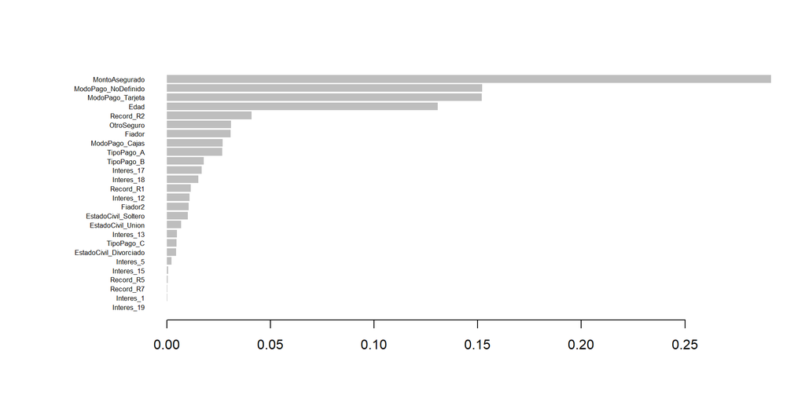

```r
key_variables <- xgb.importance(feature_names = colnames(training_matrix), model = model_xgb)
xgb.plot.importance(importance_matrix = key_variables)
```

### g. NNET

#### i. Conversion of Categorical to Numeric Variables in a Dataframe

```r
seguro_numeric <- seguro
factor_cols <- sapply(seguro_numeric, is.factor)
seguro_numeric[factor_cols] <- lapply(seguro_numeric[factor_cols], function(x) as.numeric(as.factor(x)))
```

#### ii. Training and Testing Tables

```r
training_table_nnet <- seguro_numeric[-sample, ]
testing_table_nnet <- seguro_numeric[sample, ]
```

#### iii. Balancing Data

```r
library(ROSE)

balanced_data <- ROSE(Fraude ~ ., data = testing_table_nnet, seed = 1)$data
```

#### iv. Data Preparation for Classification Models

```r
predictors <- balanced_data[, -which(names(balanced_data) == "Fraude")]
predictors_normalized <- scale(predictors)
training_table_normalized <- as.data.frame(predictors_normalized)
training_table_normalized$Fraude <- as.factor(balanced_data$Fraude)
```

#### v. Model

```r
library(caret)

model_nnet <- train(
  Fraude ~ ., data = training_table_normalized, method = "nnet",
  trControl = trainControl(method = "cv", number = 5),
  tuneLength = 5, trace = FALSE, maxit = 2000
)

# Normalize the predictor variables in the test set
predictors_test <- scale(testing_table_nnet[, -which(names(testing_table_nnet) == "Fraude")])

# Predictions in the test set
prediction_nnet <- predict(model_nnet, newdata = as.data.frame(predictors_test))

# Create the confusion matrix
cm_nnet <- table(testing_table$Fraude, prediction_nnet)

res_nnet <- calculate_metrics(cm_nnet)
```

### h. Neuralnet

#### i. Loading and cleaning Data

```r
seguro_neuralnet <- read.csv(
  "Seguros.csv",
  header = TRUE,
  stringsAsFactors = TRUE,
  sep = ";"
)
```

```r
seguro_neuralnet$Interes <- factor(seguro_neuralnet$Interes, ordered = TRUE)
seguro_neuralnet$Fiador <- ifelse(seguro_neuralnet$Fiador == "Si", "1", "0")
seguro_neuralnet$Fiador2 <- ifelse(seguro_neuralnet$Fiador2 == "Si", "1", "0")
seguro_neuralnet$OtroSeguro <- ifelse(seguro_neuralnet$OtroSeguro == "Si", "1", "0")
seguro_neuralnet$Fraude <- ifelse(seguro_neuralnet$Fraude == "Si", "1", "0")
```

#### ii. Dummy Variables

```r
seguro_neuralnet_dummy <- dummy(seguro_neuralnet[-c(3,6:8,10,12)])

seguro_clean_neuralnet <- cbind(seguro_neuralnet[-c(1,2,4,5,9,11)], seguro_neuralnet_dummy)
seguro_clean_neuralnet <- as.data.frame(lapply(seguro_clean_neuralnet, as.numeric))
```

```r
seguro_clean_neuralnet[, -6] <- scale(seguro_clean_neuralnet[, -6])
head(seguro_clean_neuralnet)
```

|  | MontoAsegurado | Fiador | Fiador2 | OtroSeguro | Edad | Fraude | Interes_0 | Interes_1 | Interes_2 | Interes_3 | Interes_4 | Interes_5 | Interes_8 | Interes_10 | Interes_11 | Interes_12 | Interes_13 | Interes_14 | Interes_15 | Interes_16 | Interes_17 | Interes_18 | Interes_19 | Tipo_Internacional | Tipo_Nacional | TipoPago_A | TipoPago_B | TipoPago_C | ModoPago_Cajas | … |
| --- | --- | --- | --- | --- | --- | --- | --- | --- | --- | --- | --- | --- | --- | --- | --- | --- | --- | --- | --- | --- | --- | --- | --- | --- | --- | --- | --- | --- | --- | --- |
| 1 | -0.4984246 | -0.9778685 | -0.4003486 | 2.193945 | 0.5183709 | 0 | -0.01766112 | -0.1466298 | -0.01248732 | -0.01248732 | -0.02163205 | -0.1803271 | -0.04506588 | -0.01248732 | -0.01766112 | -0.3378224 | -0.1875745 | -0.06739361 | -0.05450754 | -0.04329451 | 0.9867554 | -0.6055884 | -0.1536868 | -0.2376943 | 0.2376943 | 0.7363718 | -0.6287147 | -0.2707287 | -0.3233121 | … |
| 2 | -0.7480604 | 1.0224730 | 2.4974339 | 2.193945 | -1.1530979 | 0 | -0.01766112 | -0.1466298 | -0.01248732 | -0.01248732 | -0.02163205 | -0.1803271 | -0.04506588 | -0.01248732 | -0.01766112 | -0.3378224 | -0.1875745 | -0.06739361 | -0.05450754 | -0.04329451 | 0.9867554 | -0.6055884 | -0.1536868 | -0.2376943 | 0.2376943 | 0.7363718 | -0.6287147 | -0.2707287 | -0.3233121 | … |
| 3 | -0.2597718 | -0.9778685 | -0.4003486 | 2.193945 | -1.1530979 | 0 | -0.01766112 | -0.1466298 | -0.01248732 | -0.01248732 | -0.02163205 | -0.1803271 | -0.04506588 | -0.01248732 | -0.01766112 | 2.9596738 | -0.1875745 | -0.06739361 | -0.05450754 | -0.04329451 | -1.0132643 | -0.6055884 | -0.1536868 | -0.2376943 | 0.2376943 | 0.7363718 | -0.6287147 | -0.2707287 | -0.3233121 | … |
| 4 | 3.7453885 | -0.9778685 | -0.4003486 | -0.455729 | 0.7571522 | 0 | -0.01766112 | -0.1466298 | -0.01248732 | -0.01248732 | -0.02163205 | -0.1803271 | -0.04506588 | -0.01248732 | -0.01766112 | -0.3378224 | -0.1875745 | -0.06739361 | -0.05450754 | -0.04329451 | 0.9867554 | -0.6055884 | -0.1536868 | -0.2376943 | 0.2376943 | -1.3577978 | 1.5902986 | -0.2707287 | -0.3233121 | … |
| 5 | -0.1883764 | 1.0224730 | -0.4003486 | -0.455729 | -1.1530979 | 0 | -0.01766112 | -0.1466298 | -0.01248732 | -0.01248732 | -0.02163205 | -0.1803271 | -0.04506588 | -0.01248732 | -0.01766112 | -0.3378224 | -0.1875745 | -0.06739361 | -0.05450754 | -0.04329451 | 0.9867554 | -0.6055884 | -0.1536868 | -0.2376943 | 0.2376943 | 0.7363718 | -0.6287147 | -0.2707287 | -0.3233121 | … |
| 6 | -0.4984246 | 1.0224730 | -0.4003486 | -0.455729 | -0.6755354 | 0 | -0.01766112 | -0.1466298 | -0.01248732 | -0.01248732 | -0.02163205 | -0.1803271 | -0.04506588 | -0.01248732 | -0.01766112 | -0.3378224 | -0.1875745 | -0.06739361 | -0.05450754 | -0.04329451 | 0.9867554 | -0.6055884 | -0.1536868 | -0.2376943 | 0.2376943 | -1.3577978 | 1.5902986 | -0.2707287 | -0.3233121 | … |

#### iv. Formula to get all variables

```r
names <- colnames(seguro_clean_neuralnet)
formula <- as.formula(paste(
  "Fraude ~",
  paste(names[!names %in% c("Fraude")],
        collapse = " + ")))
```

#### v. Training and Testing Tables

```r
size_neuralnet <- dim(seguro_clean_neuralnet)
n_neuralnet <- size_neuralnet[1]
sample_neuralnet <- sample(1:n_neuralnet, floor(n_neuralnet*0.25))

training_table_neuralnet <- seguro_clean_neuralnet[-sample_neuralnet, ]
testing_table_neuralnet  <- seguro_clean_neuralnet[sample_neuralnet, ]
```

#### vi. Model

```r
library(neuralnet)

model_neuralnet <- neuralnet(
  formula, data = training_table_neuralnet,
  hidden = c(6,4,3), linear.output = FALSE,
  threshold = 0.1, stepmax = 1e+06
)

prediction_neuralnet <- neuralnet::compute(model_neuralnet, testing_table_neuralnet[, -6])$net.result
prediction_neuralnet <- as.factor(round(prediction_neuralnet, digits = 0))

# confusion matrix
cm_neuralnet <- table(testing_table_neuralnet$Fraude, prediction_neuralnet)
res_neuralnet <- calculate_metrics(cm_neuralnet)
```

## 5. Uncalibrated Model DataFrame

As can be seen below, the models have a fairly high accuracy but there are two models that stand out by a little *k-Nearest Neighbor* and *Decision Tree* with an accuracy of `0.9638`. In this case these two models differ by their other indicators, but the best one is *Decision Tree* since it has a positive precision of `0.9678` compared to *k-Nearest Neighbor* which has a precision of `0.9661`.

| Model | Global_Accuracy | Global_Error | Positive_Precision | Negative_Precision | False_Positives | False_Negatives | Positive_Assertivity | Negative_Assertivity |
| --- | --- | --- | --- | --- | --- | --- | --- | --- |
| k-Nearest Neighbor | 0.9638 | 0.0362 | 0.9661 | 0.9974 | 0.0026 | 0.0339 | 0.9974 | 0.9661 |
| Decision Tree | 0.9638 | 0.0362 | 0.9678 | 0.9955 | 0.0045 | 0.0322 | 0.9955 | 0.9678 |
| Random Forests | 0.9632 | 0.0368 | 0.9666 | 0.9961 | 0.0039 | 0.0334 | 0.9961 | 0.9666 |
| Kernel Linear | 0.9613 | 0.0387 | 0.9613 | 1.0000 | 0.0000 | 0.0387 | 1.0000 | 0.9613 |
| Kernel Radial | 0.9613 | 0.0387 | 0.9613 | 1.0000 | 0.0000 | 0.0387 | 1.0000 | 0.9613 |
| Kernel Polynomial | 0.9613 | 0.0387 | 0.9613 | 1.0000 | 0.0000 | 0.0387 | 1.0000 | 0.9613 |
| Kernel Sigmoid | 0.9595 | 0.0405 | 0.9612 | 0.9981 | 0.0019 | 0.0388 | 0.9981 | 0.9612 |
| Adaptive Boosting (ADA) | 0.9632 | 0.0368 | 0.9678 | 0.9948 | 0.0052 | 0.0322 | 0.9948 | 0.9678 |
| eXtreme Gradient Boosting (XGB) | 0.9570 | 0.0430 | 0.9857 | 0.9699 | 0.0301 | 0.0143 | 0.9699 | 0.9857 |
| NNET | 0.8702 | 0.1298 | 0.9941 | 0.8702 | 0.1298 | 0.0059 | 0.8702 | 0.9941 |

[output cut: 1 more lines]

## 6. Density Plots

Density plots will help us to determine which are the best variables to use to predict the `Fraude` variable.

### Quantitative Variables

In density plots for numerical variables, it is important to ensure that the densities are as non-overlapping as possible. This facilitates visual comparison and makes it possible to identify patterns or differences between the distributions of the variables.

#### a. Monto Asegurado

The `MontoAsegurado` variable is a very poor predictor as it is highly overlapping.

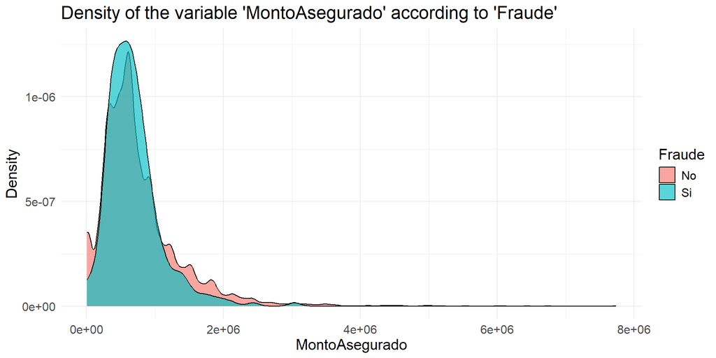

#### b. Edad

The `Edad` variable is also a very poor predictor variable for the same reason, it is very overlapping.

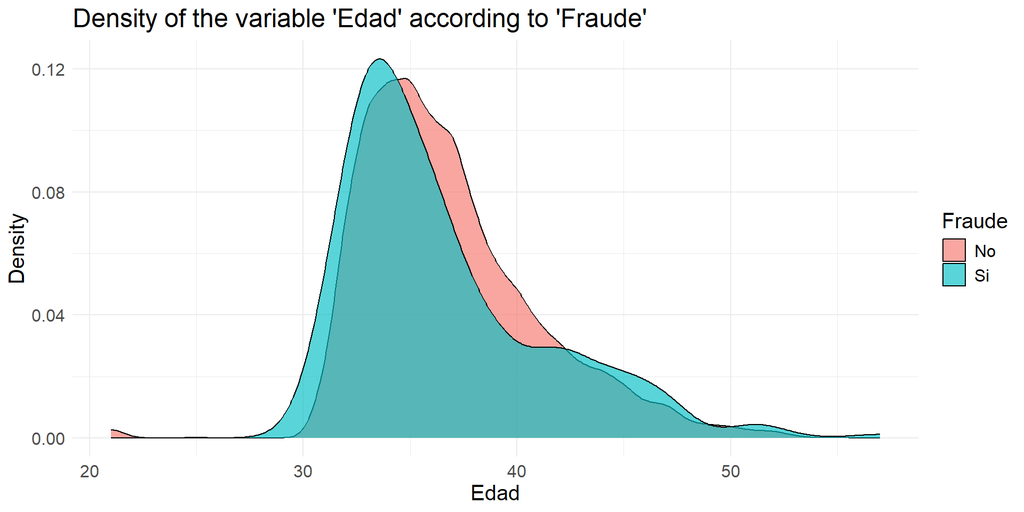

### Qualitative Variables

#### a. Interes

The variable `Interes` is a very bad predictor variable, since in the great majority of observations it has 100% of the observation, the only one that can be useful is `Interes 15`, which contains a considerable separation with respect to the others.

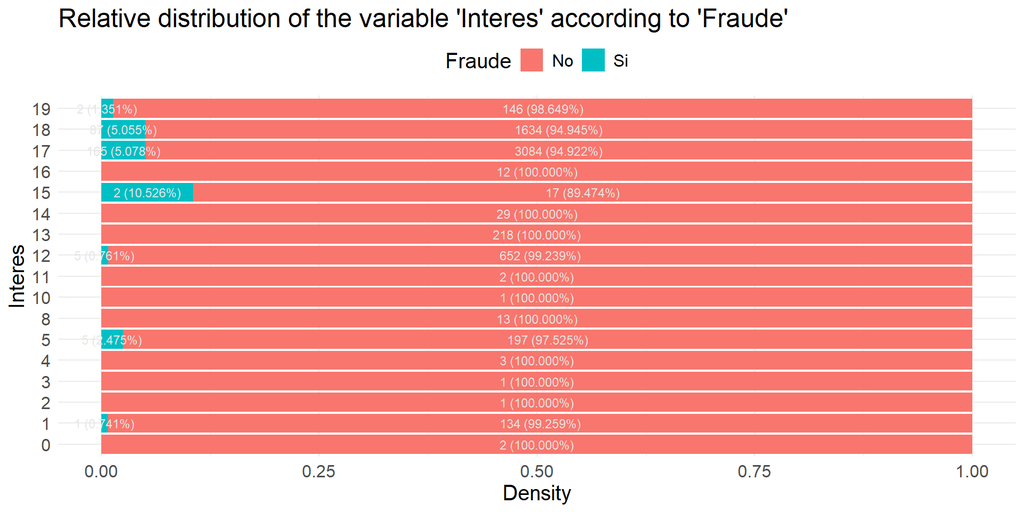

#### b. Tipo

The `Tipo` variable is a very poor predictor variable, because it has a large imbalance of the observation Si and cannot become as significant to use in the model.

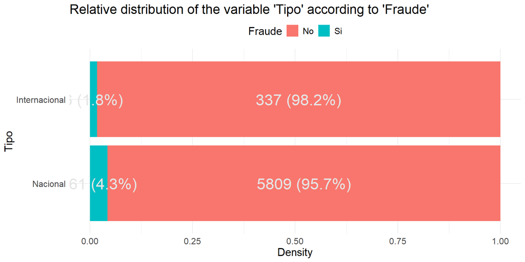

#### c. Tipo Pago

The `TipoPago` variable is also a very poor predictor variable, because it does not have a considerable separation.

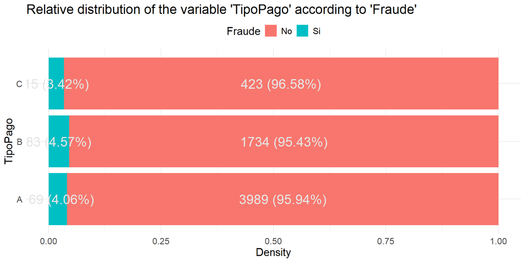

#### d. Modo Pago

The `ModoPago` variable is very good, since it has a good distribution of observations except for the `Tarjeta` observation, which has a distribution of almost zero.

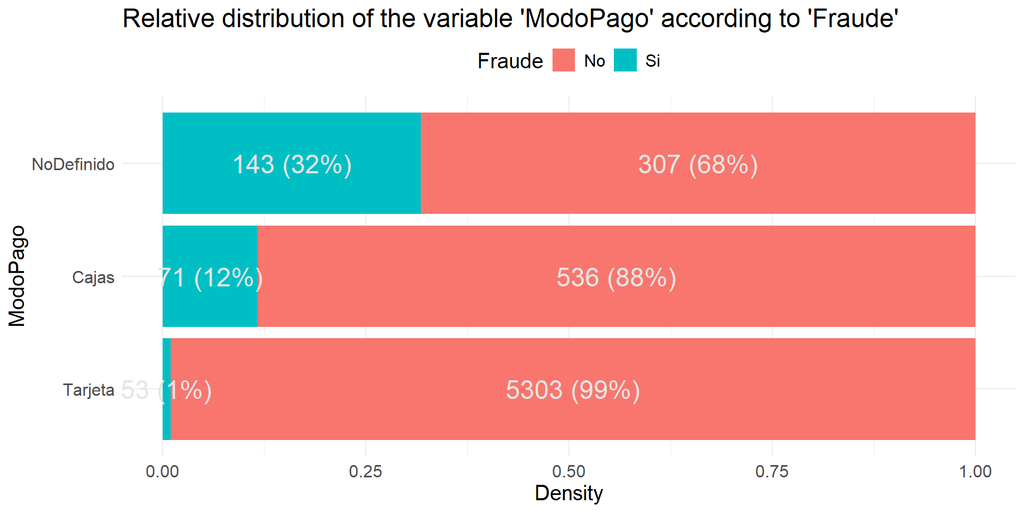

#### e. Fiador

The `Fiador` variable is a bad variable because it has a low distribution of its observations.

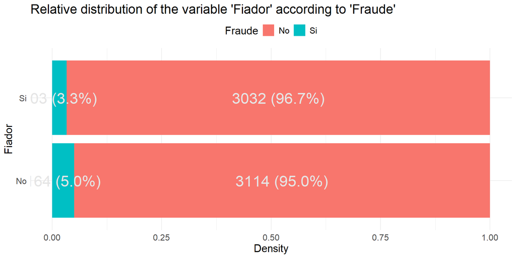

#### f. Fiador 2

The `Fiador 2` variable is a bad variable because it has a low distribution of its observations.

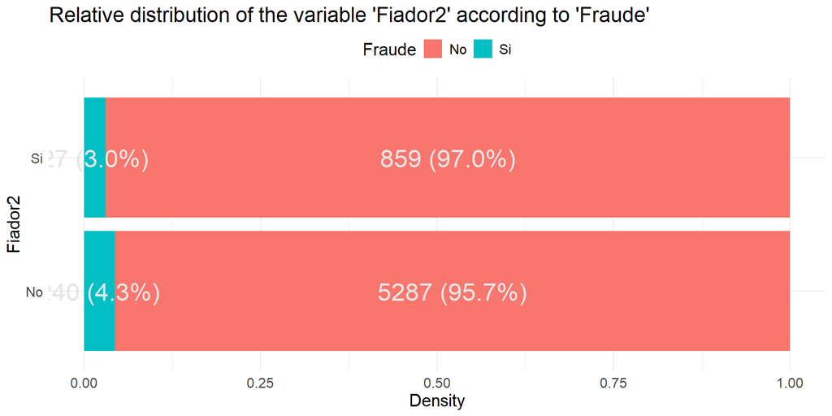

#### g. Otro Seguro

The variable `OtroSeguro` is a poor predictor variable, but the observation of `Si` could be used as it has a decent distribution, but I don’t think it would make a significant change to the accuracy of the model.

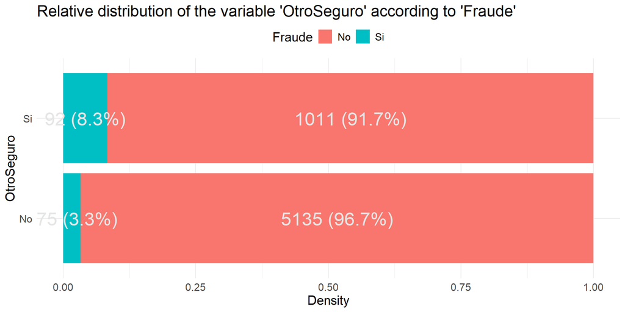

#### h. Record

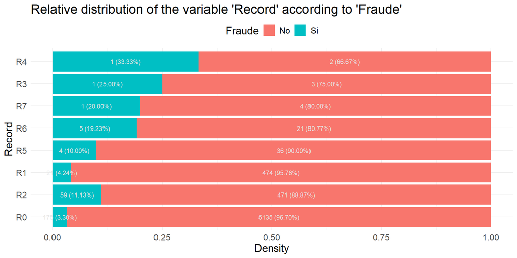

#### i. Estado Civil

The `EstadoCivil` variable is a poor predictor variable but the observation of `Viudo` can be rescued as it has a decent distribution.

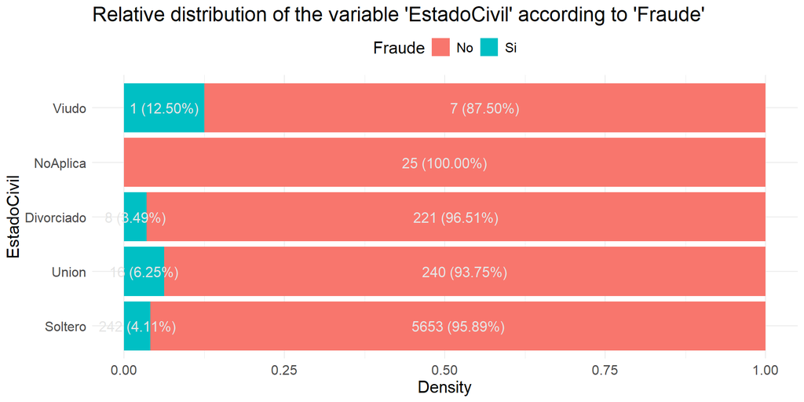

## 7. Predictive models calibrated with variable selection

Next, the predictive models will be calibrated with the best variables that were analyzed in the section on density plots, in this case the variables will be used:

- `ModoPago`
- `Record`

For models that use dummy variables, the following will be used:

- `Interes_15`
- `ModoPago_NoDefinido`
- `ModoPago_Cajas`
- `EstadoCivil_Viudo`
- `Record_R2`
- `Record_R3`
- `Record_R4`
- `Record_R5`
- `Record_R6`
- `Record_R7`

### a. k-Nearest Neighbor Classifier

```r
model_kknn_adj <- train.kknn(Fraude ~ ModoPago+Record, data = training_table, kmax = floor(sqrt(n)))
prediction_kknn_adj <- predict(model_kknn_adj, testing_table[, -12])
cm_kknn_adj <- table(testing_table[, 12], prediction_kknn_adj)
res_kknn_adj <- calculate_metrics(cm_kknn_adj)
```

### b. Decision Trees

```r
model_DT_adj <- rpart(Fraude ~ ModoPago+Record, data = training_table, minsplit = 2)
prediction_DT_adj <- predict(model_DT_adj, testing_table, type = "class")
cm_DT_adj <- table(testing_table$Fraude, prediction_DT_adj)
res_DT_adj <-  calculate_metrics(cm_DT_adj)
```

### c. Random Trees

```r
model_RF_adj <- randomForest(Fraude ~ ModoPago+Record, data = training_table, importance = TRUE, ntree = 1000, mtry = 2)
prediction_RF_adj <- predict(model_RF_adj, testing_table[, -12])
cm_RF_adj <- table(testing_table$Fraude, prediction_RF_adj)
res_RF_adj <- calculate_metrics(cm_RF_adj)
```

### d. Support Vector Machines (SVM)

#### i. Kernel Linear

```r
model_linear_adj <- svm(Fraude ~ ModoPago+Record, data = training_table, kernel = "linear")
prediction_linear_adj <- predict(model_linear_adj, testing_table)
cm_linear_adj <- table(testing_table[, 12], prediction_linear_adj)
res_linear_adj <- calculate_metrics(cm_linear_adj)
```

#### ii. Kernel Radial

```r
model_radial_adj <- svm(Fraude ~ ModoPago+Record, data = training_table, kernel = "radial")
prediction_radial_adj <- predict(model_radial_adj, testing_table)
cm_radial_adj <- table(testing_table[, 12], prediction_radial_adj)
res_radial_adj <- calculate_metrics(cm_radial_adj)
```

#### iii. Kernel Polynomial

```r
model_polynomial_adj <- svm(Fraude ~ ModoPago+Record, data = training_table, kernel = "polynomial")
prediction_polynomial_adj <- predict(model_polynomial_adj, testing_table)
cm_polynomial_adj <- table(testing_table[, 12], prediction_polynomial_adj)
res_polynomial_adj <- calculate_metrics(cm_polynomial_adj)
```

#### iv. Kernel Sigmoid

```r
model_sigmoid_adj <- svm(Fraude ~ ModoPago+Record, data = training_table, kernel = "sigmoid")
prediction_sigmoid_adj <- predict(model_sigmoid_adj, testing_table)
cm_sigmoid_adj <- table(testing_table[, 12], prediction_sigmoid_adj)
res_sigmoid_adj <- calculate_metrics(cm_sigmoid_adj)
```

### e. Adaptive Boosting (ADA)

```r
model_ada_adj <- ada(
  Fraude ~ ModoPago+Record, data = training_table, iter = 100, type = 'real',
  control = rpart.control(minsplit = 2, maxdepth = 30)
)
prediction_ada_adj <- predict(model_ada_adj, testing_table[, -12])
cm_ada_adj <- table(testing_table$Fraude, prediction_ada_adj)
res_ada_adj <- calculate_metrics(cm_ada_adj)
```

### f. eXtreme Gradient Boosting (XGB)

#### i. Training and Testing Matrix

```r
training_matrix_adj <- xgb.DMatrix(
  data = data.matrix(training_table_xgb[, -c(1:18,20:28,31,41)]),
  label = data.matrix(training_table_xgb$Fraude)
)

testing_matrix_adj <- xgb.DMatrix(
  data = data.matrix(testing_table_xgb[, -c(1:18,20:28,31,41)]),
  label = data.matrix(testing_table_xgb$Fraude)
)
```

#### ii. Model

```r
parameters <- list(
  booster = "gbtree", objective = "binary:logistic", eta = 0.3, gamma = 0,
  max_depth = 6, min_child_weight = 1, subsample = 1, colsample_bytree = 1
)
model_xgb_adj <- xgb.train (
  params = parameters, data = training_matrix_adj, nrounds = 79,
  watchlist = list(train = training_matrix_adj, test = testing_matrix_adj),
  print_every_n = 10, early_stop_round = 10, maximize = FALSE , eval_metric = "error"
)
```

```
## [19:10:20] WARNING: src/learner.cc:767:
## Parameters: { "early_stop_round" } are not used.
##
```

```r
prediction_xgb_adj <- predict(model_xgb_adj, testing_matrix_adj)
prediction_xgb_adj <- ifelse(prediction_xgb_adj > 0.5, 1, 0)

cm_xgb_adj <- table(prediction_xgb_adj, predicted_var)
res_xgb_adj <- calculate_metrics(cm_xgb_adj)
```

### g. NNET

```r
model_nnet_adj <- train(
  Fraude ~ ModoPago+Record, data = training_table_normalized, method = "nnet",
  trControl = trainControl(method = "cv", number = 5),
  tuneLength = 5, trace = FALSE, maxit = 2000
)

# Normalize the predictor variables in the test set
predictors_test_adj <- scale(testing_table_nnet[, -which(names(testing_table_nnet) == "Fraude")])

# Predictions in the test set
prediction_nnet_adj <- predict(model_nnet_adj, newdata = as.data.frame(predictors_test_adj))

# Create the confusion matrix
cm_nnet_adj <- table(testing_table_nnet$Fraude, prediction_nnet_adj)

res_nnet_adj <- calculate_metrics(cm_nnet_adj)
```

### h. Neuralnet

#### i. Formula to get the best predictors

```r
formula_adj <- as.formula(paste(
  "Fraude ~ Interes_15+ModoPago_NoDefinido+ModoPago_Cajas+EstadoCivil_Viudo+Record_R2+Record_R3+Record_R4+Record_R5+Record_R6+Record_R7"
))
```

#### ii. Model

```r
model_neuralnet_adj <- neuralnet(
  formula_adj, data = training_table_neuralnet,
  hidden = c(6,4,3), linear.output = FALSE,
  threshold = 0.1, stepmax = 1e+06
)

prediction_neuralnet_adj <- neuralnet::compute(model_neuralnet_adj, testing_table_neuralnet[, -6])$net.result
prediction_neuralnet_adj <- as.factor(round(prediction_neuralnet_adj, digits = 0))

cm_original <- table(testing_table_neuralnet$Fraude, prediction_neuralnet_adj)

# Check if all predictions are equal to 0
if(all(prediction_neuralnet_adj == 0)) {
  # Create a confusion matrix with zeros instead of prediction_neuralnet_adj
  actual_levels <- levels(factor(testing_table_neuralnet$Fraude))
  predicted_levels <- c("0", "1")  # Assuming binary levels

  # Create an empty matrix with unique levels as row and column names
  cm_neuralnet_adj <- matrix(0, nrow = length(actual_levels), ncol = length(predicted_levels),
                              dimnames = list(actual_levels, predicted_levels))

  # Fill the matrix with values from the original confusion matrix
  cm_neuralnet_adj[rownames(cm_original), colnames(cm_original)] <- cm_original
} else {
  # If not all predictions are zero, keep the original confusion matrix
  cm_neuralnet_adj <- cm_original
}
res_neuralnet_adj <- calculate_metrics(cm_neuralnet_adj)
```

## 8. Models DataFrame

In this new dataframe, with the models already calibrated, it can be seen that their accuracy is similar to the uncalibrated models, the model with the highest accuracy is *Random Forest* with `0.9632`, but this does not surpass the best uncalibrated model which had a `0.9638`.

| Model | Global_Accuracy | Global_Error | Positive_Precision | Negative_Precision | False_Positives | False_Negatives | Positive_Assertivity | Negative_Assertivity |
| --- | --- | --- | --- | --- | --- | --- | --- | --- |
| k-Nearest Neighbor | 0.9426 | 0.0574 | 0.9808 | 0.9591 | 0.0409 | 0.0192 | 0.9591 | 0.9808 |
| Decision Tree | 0.9626 | 0.0374 | 0.9643 | 0.9981 | 0.0019 | 0.0357 | 0.9981 | 0.9643 |
| Random Forests | 0.9632 | 0.0368 | 0.9684 | 0.9942 | 0.0058 | 0.0316 | 0.9942 | 0.9684 |
| Kernel Linear | 0.9613 | 0.0387 | 0.9613 | 1.0000 | 0.0000 | 0.0387 | 1.0000 | 0.9613 |
| Kernel Radial | 0.9613 | 0.0387 | 0.9613 | 1.0000 | 0.0000 | 0.0387 | 1.0000 | 0.9613 |
| Kernel Polynomial | 0.9613 | 0.0387 | 0.9613 | 1.0000 | 0.0000 | 0.0387 | 1.0000 | 0.9613 |
| Kernel Sigmoid | 0.9613 | 0.0387 | 0.9613 | 1.0000 | 0.0000 | 0.0387 | 1.0000 | 0.9613 |
| Adaptive Boosting (ADA) | 0.9619 | 0.0381 | 0.9619 | 1.0000 | 0.0000 | 0.0381 | 1.0000 | 0.9619 |
| eXtreme Gradient Boosting (XGB) | 0.9619 | 0.0381 | 0.9955 | 0.9660 | 0.0340 | 0.0045 | 0.9660 | 0.9955 |
| NNET | 0.9370 | 0.0630 | 0.9905 | 0.9435 | 0.0565 | 0.0095 | 0.9435 | 0.9905 |

[output cut: 1 more lines]

## 9. Applying the best model

The best model (Decision Tree) applied to a file with zero fraud values is presented below. It can be seen that the model was only able to predict only 5 profiles that can commit fraud.

```r
seguro_na <- read.csv(
  "SegurosNA.csv",
  header = TRUE,
  stringsAsFactors = TRUE,
  sep = ";"
)

# Verify and transform the data
seguro_na$Interes <- factor(seguro_na$Interes, ordered = TRUE)

# Making predictions with the trained model
predictions_na <- predict(model_DT, newdata = seguro_na, type = "class")

# Assign the predictions to the Fraud column in seguro_na
seguro_na$Fraude <- predictions_na

seguro_na_si <- subset(seguro_na, Fraude == "Si")
head(seguro_na_si)
```

|  | Interes | Tipo | MontoAsegurado | TipoPago | ModoPago | Fiador | Fiador2 | OtroSeguro | Record | Edad | EstadoCivil | Fraude |
| --- | --- | --- | --- | --- | --- | --- | --- | --- | --- | --- | --- | --- |
| 80 | 17 | Nacional | 613582 | B | Cajas | Si | No | Si | R2 | 36 | Soltero | Si |
| 119 | 18 | Nacional | 613581 | B | Cajas | Si | No | Si | R2 | 33 | Soltero | Si |
| 255 | 17 | Nacional | 548430 | A | NoDefinido | Si | No | Si | R2 | 33 | Soltero | Si |
| 330 | 17 | Nacional | 1219643 | B | Cajas | No | No | Si | R2 | 34 | Soltero | Si |
| 366 | 17 | Nacional | 916612 | B | Cajas | Si | Si | Si | R4 | 50 | Soltero | Si |